# Linear Regression

# Upload data

```r
info_train <- read.csv2("udemy_train.csv", header = TRUE, encoding = "UNICOD")
info_train <- info_train[,-1]
info_test <- read.csv2("udemy_test.csv", header = TRUE, encoding = "UNICOD")
info_test <- info_test[,-1]
```

# Simple Linear Regression (one factor num_published_lectures)

## Fitting Simple Linear Regression to the Training set

```r
model_sr <- lm(price_detail__amount ~ num_published_lectures, info_train)
summary(model_sr)
```

```
##
## Call:
## lm(formula = price_detail__amount ~ num_published_lectures, data = info_train)
##
## Residuals:
##      Min       1Q   Median       3Q      Max
## -11451.9  -2740.8   -972.3   2958.3   8860.3
##
## Coefficients:
##                        Estimate Std. Error t value Pr(>|t|)
## (Intercept)            3838.191     35.417  108.37   <2e-16 ***
## num_published_lectures   20.295      0.643   31.56   <2e-16 ***
## ---
## Signif. codes:  0 '***' 0.001 '**' 0.01 '*' 0.05 '.' 0.1 ' ' 1
##
## Residual standard error: 3057 on 11598 degrees of freedom
## Multiple R-squared:  0.07911,    Adjusted R-squared:  0.07903
## F-statistic: 996.3 on 1 and 11598 DF,  p-value: < 2.2e-16
```

#### Conclusion: selected variable is significant. Coefficient of determination is almost 0.08

## Predicting

```r
p_sr <- predict(model_sr, info_test)

r2_sr <- 1-sum((info_train$price_detail__amount - predict(model_sr, info_train))^2)/sum((info_train$price_detail__amount - mean(info_train$price_detail__amount))^2)
R2_sr <- cor(info_train$price_detail__amount, fitted(model_sr))^2 #simplier ex.

train_mse_sr <- sum((info_train$price_detail__amount-predict(model_sr, info_train))^2)/length(info_train$price_detail__amount)
test_mse_sr <- sum((info_test$price_detail__amount-p_sr)^2)/length(p_sr)

r2_sr
```

```
## [1] 0.07910715
```

```r
R2_sr
```

```
## [1] 0.07910715
```

```r
train_mse_sr
```

```
## [1] 9344535
```

```r
test_mse_sr
```

```
## [1] 8943713
```

#### Conclusion: coefficients of determination are calculated manually. The value of the root mean square error in the training sample - 9344535, in the test sample - 8943713, ie there is no retraining.

## Visualising

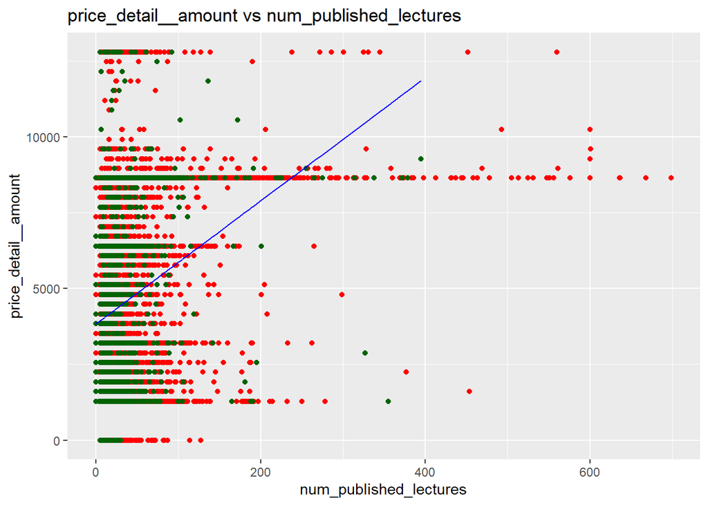

```r
library(ggplot2)
ggplot() +
  geom_point(aes(info_train$num_published_lectures, info_train$price_detail__amount),colour = 'red') +
  geom_point(aes(info_test$num_published_lectures, info_test$price_detail__amount),colour = 'dark green') +
  geom_line(aes(info_test$num_published_lectures, p_sr),colour = 'blue') +
  ggtitle('price_detail__amount vs num_published_lectures') +
  xlab('num_published_lectures') +
  ylab('price_detail__amount')
```

#### Conclusion: Points of the training sample are marked in red, points of the test sample are marked in green, and the model values are marked in blue.

# Multiple Linear Regression (many factors)

## All factors

```r
model_mr <- lm(data = info_train, price_detail__amount ~ .)
summary(model_mr)
```

```
##
## Call:
## lm(formula = price_detail__amount ~ ., data = info_train)
##
## Residuals:
##     Min      1Q  Median      3Q     Max
## -8916.4 -2645.8  -730.6  2461.7 10169.7
##
## Coefficients:
##                          Estimate Std. Error t value Pr(>|t|)
## (Intercept)            -1.639e+03  1.748e+02  -9.382   <2e-16 ***
## is_paidTRUE             4.190e+03  1.485e+02  28.224   <2e-16 ***
## num_subscribers         7.454e-02  5.273e-03  14.137   <2e-16 ***
## rating                  2.374e+02  2.676e+01   8.873   <2e-16 ***
## num_published_lectures  1.598e+01  6.310e-01  25.317   <2e-16 ***
## discount_price__amount  1.021e+00  9.543e-02  10.697   <2e-16 ***
## ---
## Signif. codes:  0 '***' 0.001 '**' 0.01 '*' 0.05 '.' 0.1 ' ' 1
##
## Residual standard error: 2889 on 11594 degrees of freedom
## Multiple R-squared:  0.1778, Adjusted R-squared:  0.1775
## F-statistic: 501.5 on 5 and 11594 DF,  p-value: < 2.2e-16
```

#### Conclusion: All variables are significant. Model doesn't need optimization. Coefficient of determination is 0.18

## Predicting

```r
p_mr <- predict(model_mr, info_test)

train_mse_opt <- sum((info_train$price_detail__amount-predict(model_mr, info_train))^2)/length(info_train$price_detail__amount)
test_mse_opt <- sum((info_test$price_detail__amount-p_mr)^2)/length(p_mr)

train_mse_opt
```

```
## [1] 8342950
```

```r
test_mse_opt
```

```
## [1] 8313318
```

#### Conclusion: The value of the root mean square error improved: in the training sample - 8342950, in the test sample - 8313318, ie there is no retraining.

## Visualising

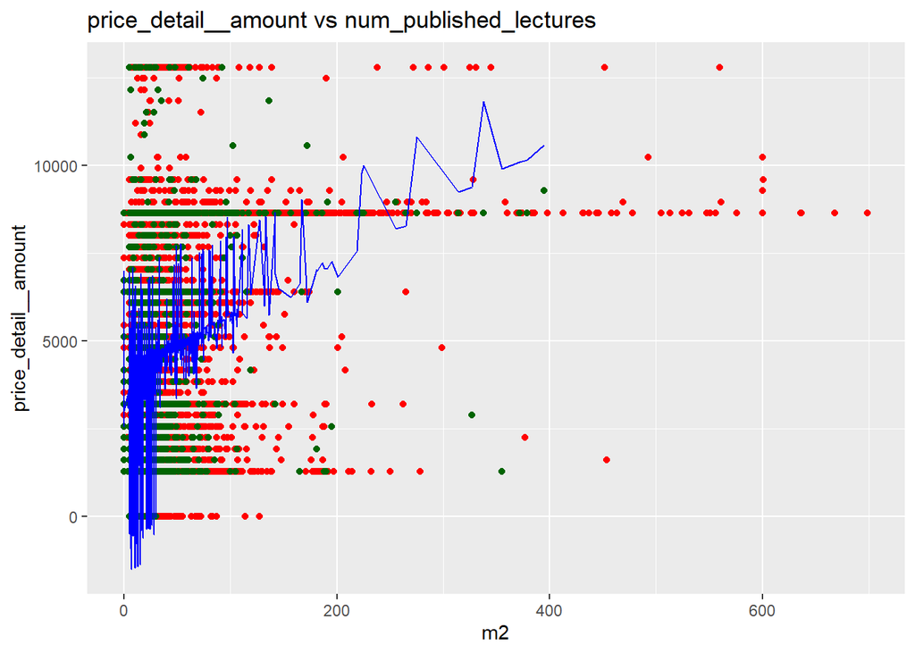

```r
ggplot() +
  geom_point(aes(info_train$num_published_lectures, info_train$price_detail__amount),colour = "red") +
  geom_point(aes(info_test$num_published_lectures, info_test$price_detail__amount),colour = "dark green")+ geom_line(aes(info_test$num_published_lectures, p_mr),colour = "blue") + ggtitle("price_detail__amount vs num_published_lectures") + xlab("m2") +  ylab("price_detail__amount")
```

#### Conclusion: Points of the training sample are marked in red, points of the test sample are marked in green, and the model values are marked in blue.

# Polynomial Linear Regression (one factor num_published_lectures)

## Features extending

```r
info_train_poly <- info_train[,c("price_detail__amount", "num_published_lectures")]
info_test_poly <- info_test[,c("price_detail__amount", "num_published_lectures")]
info_train_poly$num_published_lectures2 <- info_train_poly$num_published_lectures^2
info_train_poly$num_published_lectures3 <- info_train_poly$num_published_lectures^3
info_test_poly$num_published_lectures2 <- info_test_poly$num_published_lectures^2
info_test_poly$num_published_lectures3 <- info_test_poly$num_published_lectures^3
```

#### Conclusion: Variables num_published_lectures^2 and num_published_lectures^3 are added.

## 3 powers

```r
model_pr <- lm(data = info_train_poly, price_detail__amount ~ num_published_lectures2 + num_published_lectures3)
summary(model_pr)
```

```
##
## Call:
## lm(formula = price_detail__amount ~ num_published_lectures2 +
##     num_published_lectures3, data = info_train_poly)
##
## Residuals:
##    Min     1Q Median     3Q    Max
## -11131  -2972  -1078   3311  10846
##
## Coefficients:
##                           Estimate Std. Error t value Pr(>|t|)
## (Intercept)              4.247e+03  3.057e+01  138.94   <2e-16 ***
## num_published_lectures2  1.419e-01  6.091e-03   23.30   <2e-16 ***
## num_published_lectures3 -2.219e-04  1.136e-05  -19.53   <2e-16 ***
## ---
## Signif. codes:  0 '***' 0.001 '**' 0.01 '*' 0.05 '.' 0.1 ' ' 1
##
## Residual standard error: 3098 on 11597 degrees of freedom
## Multiple R-squared:  0.05413,    Adjusted R-squared:  0.05397
## F-statistic: 331.8 on 2 and 11597 DF,  p-value: < 2.2e-16
```

#### Conclusion: Variables num_published_lectures^2 and num_published_lectures^3 are significant. Coefficient of determination dropped - 0.05

## Predicting

```r
p_pr <- predict(model_pr, info_test_poly)

train_mse_poly <- sum((info_train_poly$price_detail__amount-predict(model_pr, info_train_poly))^2)/length(info_train_poly$price_detail__amount)
test_mse_poly <- sum((info_test_poly$price_detail__amount-p_pr)^2)/length(p_pr)

train_mse_poly
```

```
## [1] 9597965
```

```r
test_mse_poly
```

```
## [1] 9287186
```

#### Conclusion: The value of the root mean square error increased: in the training sample - 9597965, in the test sample - 9287186, ie there is no retraining.

## Visualising

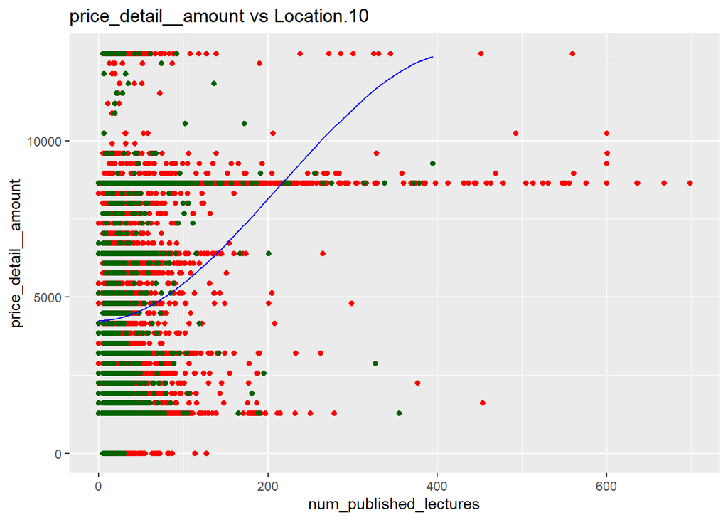

```r
ggplot() +
  geom_point(aes(info_train_poly$num_published_lectures, info_train_poly$price_detail__amount),colour = 'red') +
  geom_point(aes(info_test_poly$num_published_lectures, info_test_poly$price_detail__amount),colour = 'dark green') +
  geom_line(aes(info_test_poly$num_published_lectures, p_pr),colour = 'blue') +
  ggtitle('price_detail__amount vs Location.10') +
  xlab('num_published_lectures') +
  ylab('price_detail__amount')
```

#### Conclusion: Points of the training sample are marked in red, points of the test sample are marked in green, and the model values are marked in blue.

# Saving results

```r
fit <- data.frame(p_sr, p_mr, p_pr)
write.csv2(fit, file = "Lab3_fit.csv")
```

#### Conclusion: Simulation results are saved.